# Text Analysis on Bills

Hu, Yue

2016-07-12

This is just a short intro to input and analyze multiple .txt files from the local drive through `tm` package. For analytical convenience, we will preload some other packages for data mining and string managements.

```r
if (!require(pacman)) install.packages("pacman")
library(pacman) # package for load multiple packages together
p_load(tm, # the main analytic package
       wordcloud, # creating word clouds based on a DTM
       ggplot2, # graphing package
       stringr, # string management
       dplyr) # data mining
Sys.setlocale(locale = "C")
```

```
[1] "C"
```

## Data loading and cleaning

The first step is to locate the data. One can get the current working directory through function `getwd()`, and modify it by `setwd()`. However, if this is a project involving more than once coding, users are suggested to create a R [project](https://support.rstudio.com/hc/en-us/articles/200526207-Using-Projects). Users then don’t have to set the working directory at each time and is convenient to do version controls with Github or SVN.

After setting the working directory, one can use `DirSource` function to tell R where the files are located and input them as a `corpus` object.

```r
dir <- "../data/bills-text"
corpus_bill <- Corpus(DirSource(dir))
class(corpus_bill);names(corpus_bill)
```

```
[1] "VCorpus" "Corpus"
```

If researchers want to check the information of any single document in the corpus, they can do this:

```r
inspect(corpus_bill[2])
```

```
<<VCorpus>>
Metadata:  corpus specific: 0, document level (indexed): 0
Content:  documents: 1

[[1]]
<<PlainTextDocument>>
Metadata:  7
Content:  chars: 74407
```

```r
content(corpus_bill[[2]])[1:20]
```

```
 [1] "       UNIFORM ALCOHOLISM AND"
 [2] "     INTOXICATION TREATMENT ACT"
 [3] ""
 [4] "                Drafted by"
 [5] " NATIONAL CONFERENCE OF COMMISSIONERS"
 [6] "        ON UNIFORM STATE LAWS"
 [7] ""
 [8] "                 And by it "
 [9] "APPROVED AND RECOMMENDED FOR ENACTMENT            IN ALL THE STATES"
[10] " At its"
[11] "          ANNUAL CONFERENCE"
[12] "      MEETING IN ITS EIGHTIETH YEAR"
[13] "           AT VAIL, COLORADO"
[14] "            AUGUST 21-28, 1971"
[15] ""
[16] "    WITH PREFATORY NOTE AND COMMENTS"
[17] " 1       The committee which acted for the National Conference of Commissioners on Uniform State Laws in preparing the Uniform Alcoholism and Intoxication Treatment Act was as follows: "
[18] "ALLAD D. VESTAL, College of Law, University of Iowa, Iowa City, Iowa, Chairman RICHARD E. DAY, College of Law, Ohio State University, Columbus, Ohio HOWARD G. KULP, JR., 518 Market Street, Camden, New Jersey JEREMIAH MARSH, Suite 2100, 160 N. LaSalle Street, Chicago, Illinois THOMAS NEEDHAM, 4…
[19] "      Copies of all Uniform and Model Acts and other printed matter issued by the Conference "
[20] "may be obtained from:"
```

More than often, users care more about the substantive words than functional words (such as “to”, “of”, “for”), digits, and punctuations. To avoid their disturbing the later analysis, one needs to “clean” the texts first. It usually includes converting upper cases to lower cases, removing punctuation and non alphabetic characters, deleting white spaces (e.g., caused by double spacing), etc. Another oft-used process is to remove all the stop words (viz., functional words). Here I only show how to do some common cleanings with `tm` functions. Users can omit or add steps according to their researching goals. More functions can be found in the help file of `tm` package.

```r
corpus_bill <- tm_map(corpus_bill, PlainTextDocument) %>%
  tm_map(content_transformer(tolower)) %>% # to lower case
  tm_map(removePunctuation) %>% # remove all the punctuations
  tm_map(removeNumbers) %>% # remove numbers
  tm_map(stripWhitespace) %>% #remove empty lines
  tm_map(stemDocument) %>% #stemming the words, e.g., treating "do" and "doing" as the same word.
  tm_map(removeWords, stopwords("english"))
# A glimpse to the stop words that have been removed from the texts
stopwords("english")[1:5]
```

```
[1] "i"      "me"     "my"     "myself" "we"
```

```r
## Users can create their own stopwords based on the existing one or from a separate file
###Not run###
# stop_new <- c(stopwords("english"), "department") # adding "department" into the stopword list
# stop_new <- stop_new[stop_new != "ours"] # deleting "ours" from the stopword list
############
```

## Word Counts

A common way to do word counting and relevant analyses in R is to convert texts to word matrices, i.e., document-term matrices, in which the rows are documents and the columns are words (terms). Then one is free to count word frequency within a document or in the whole corpus.

### Calculate Word Counts

```r
dtm_bill <- DocumentTermMatrix(corpus_bill) # convert to DTM
inspect(dtm_bill[, 1:10])
```

```
<<DocumentTermMatrix (documents: 2, terms: 10)>>
Non-/sparse entries: 13/7
Sparsity           : 35%
Maximal term length: 7
Weighting          : term frequency (tf)

              Terms
Docs           abandon abid abil abl abroad absenc absent absolut abstain abus
  character(0)       5    2    6   6      1      7      2       3       0   11
  character(0)       0    0    5   3      0      0      0       0       1    7
```

Now, let’s find the most frequent words in a couple of ways:

- What words appear more than a certain frequency (e.g., 300 times)?

```r
findFreqTerms(dtm_bill, 300)
```

```
 [1] "adopt"    "ani"      "consent"  "court"    "individu" "may"      "minor"    "parent"
 [9] "section"  "state"
```

```r
freq <- as.matrix(dtm_bill) %>% t %>% as.data.frame %>% tibble::rownames_to_column(var = "term")
# convert the dtm to a dataframe for the convenience of arrangement
names(freq) <- list.files(dir) %>% str_sub(end = 4) %>% c("term", .)
# using the first four letters of each file as the column names.
# the most frequent words in Document 1
select(freq, 1:2) %>% arrange(desc(Adop)) %>% head
```

```
      term Adop
1    adopt 1220
2   parent  870
3    minor  804
4  section  410
5    court  351
6 individu  325
```

```r
# the most frequent words in Document 2
select(freq, term, Alco) %>% arrange(desc(Alco)) %>% head
```

```
       term Alco
1 treatment  217
2   alcohol  155
3     shall  147
4    person  136
5     facil   91
6    public   87
```

```r
# the most frequent words in the whole corpus
freq_df <- mutate(freq, sumFreq = Adop + Alco) %>% arrange(desc(sumFreq))
head(freq_df)
```

```
     term Adop Alco sumFreq
1   adopt 1220   32    1252
2  parent  870    5     875
3   minor  804    7     811
4 section  410   64     474
5   court  351   57     408
6     may  271   78     349
```

### Visualize Word Counts

A prevalent (yet not very informative) way to present word counts is through wordcloud. Let’s create a word cloud containing words which frequencies are above the average.

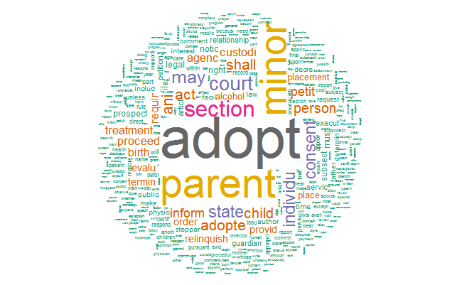

```r
wordcloud(freq_df$term, freq_df$sumFreq,
          scale=c(5,.2), min.freq=mean(freq_df$sumFreq),
          random.order=FALSE, rot.per=.15, colors=brewer.pal(8,"Dark2"))
```

## Measure Lexical Variety

- Type-Token Ratio: dividing the total number of unique word types by the total number of word tokens. (Please double check if the following calculation matches the definition of TTR. See the definition in Jockers 2014, 59.)

```r
freq_dfAg <- summarise_if(freq_df, is.numeric, sum) # calculate the sum of words
freq_dfAg$unique <- length(freq_df$term) # calculate the sum of unique words
complexity <- data.frame(doc = colnames(freq_dfAg)[-4], stringsAsFactors = F)
complexity$ttr <- freq_dfAg$unique / freq_dfAg[,1:3] %>% t
complexity
```

```
      doc        ttr
1    Adop 0.08964151
2    Alco 0.36147327
3 sumFreq 0.07182875
```

```r
length(freq_df$term[freq_df$Adop == 1]) #words only used once in Document 1
```

```
[1] 680
```

```r
complexity[,c(1, 3)]
```

[output not shown]

### Compare the lexical variety in plot

```r
complexity_dfVis <- tidyr::gather(complexity, category, variety, ttr, hapax)
complexity_dfVis$doc[complexity_dfVis$doc == "sumFreq"] <- "Corpus"
complexity_dfVis
```

```
     doc category    variety
1   Adop      ttr 0.08964151
2   Alco      ttr 0.36147327
3 Corpus      ttr 0.07182875
4   Adop    hapax 0.02748252
5   Alco    hapax 0.07692308
6 Corpus    hapax 0.02632857
```

The visualization can easily show the consistency and difference of the two measurement of document complexity.

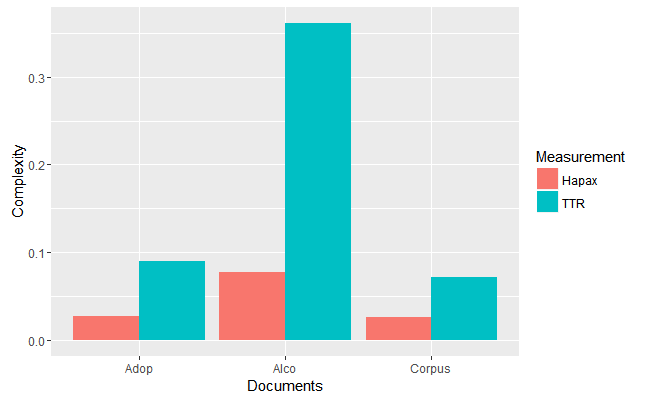

```r
ggplot(complexity_dfVis, aes(x = doc, y = variety, fill = category)) +
    geom_bar(stat="identity", position=position_dodge()) +
  xlab("Documents") + ylab("Complexity") +
  scale_fill_discrete(name = "Measurement", labels = c("Hapax", "TTR"))
```